# Functions in MIPS

# Q1

**Memory Diagram and Translation**

Draw a memory diagram at the time `##HERE` is found.

```python
def function(x,y):
    ## HERE
    if x  >= y:
        return x - y
    return 0

def main():
    x = function(27,2)
    print(x)
```

## The question

Translate the code

Reorder and comment

```python
# def main():
    # x = function(27,2)
    # print(x)

# def function(x,y):
    ## HERE
    # if x  >= y:
        # return x - y
    # return 0
```

Add labels and data

```
.data
nline: .asciiz "\n"

.text
# def main():
main:
    # x = function(27,2)
    # print(x)

# def function(x,y):
function:
    # if x >= y:
    # return x - y
endif:
    # return 0
```

The roadmap

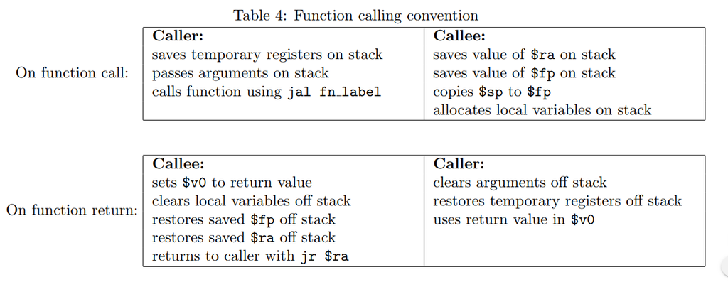

Let's look at the `main` function first

- set up frame and stack pointer
- set up arguments to be passed into `function`
- call `function`
- store the result of `function` in `x`
- print `x`
- terminate the program

```
# def main():
main:
    # setup frame pointer for main and make space for locals
    # set arguments for function
    # x = function(27,2)
    # print x and \n as (done in python)
    # terminate program
```

Setting up the main-frame

```
# def main():
main:
    # setup frame pointer for main and make space for locals
    addi $fp, $sp, 0  # copy $sp to $fp
    addi $sp, $sp, -4 # make space for one local variable: x

    # set arguments for function
    # x = function(27,2)
    # print x and \n as (done in python)
    # terminate program
```

Pushing arguments onto the stack

```
# def main():
main:
    # setup frame pointer for main and make space for locals
    addi $fp, $sp, 0  # copy $sp to $fp
    addi $sp, $sp, -4 # make space for one local variable: x

    # set arguments for function
    addi $sp, $sp, -8 # make space for 2 arguments

    # x = function(27,2)
    # print x and \n as (done in python)
    # terminate program
```

Pushing arguments onto the stack

```
# def main():
main:
    # setup frame pointer for main and make space for locals
    addi $fp, $sp, 0  # copy $sp to $fp
    addi $sp, $sp, -4 # make space for one local variable: x

    # set arguments for function
    addi $sp, $sp, -8 # make space for 2 arguments
    addi $t0, $0, 27  # get 27 in a register
    sw $t0, 0($sp)    # pass n as arg1
    addi $t0, $0, 2   # get 2 in a register
    sw $t0, 4($sp)    # pass 2 as arg2

    # x = function(27,2)
    # print x and \n as (done in python)
    # terminate program
```

Calling the function

```
    # x = function(27,2)
    jal function      # call function
    # then return
    sw $v0, -4($fp)   # set x to the return value
    addi $sp, $sp, 8  # remove space for two args on stack

    # print x and \n as (done in python)
    # terminate program
```

Print the output and terminate

```
    # print x and \n as (done in python)
    lw $a0, -4($fp) # $a0=x
    addi $v0, $0, 1 # set syscall 1
    syscall # print x

    # print nline
    la $a0, nline   # load address of nline in to $a0
    addi $v0, $0, 4 # set syscall to 4
    syscall # print newline

    # terminate program
    addi $v0, $0, 10
    syscall
```

## What about the function function?

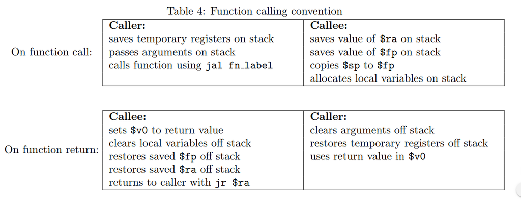

```
# def function(x,y):
function:
    # if x >= y:
    # return x - y
endif:
    # return 0
```

The general function pattern.

```
# def function(x,y):
function:
    # save $ra and $fp and update $fp
    addi $sp, $sp, -8 # make space for $fp and $ra
    sw $fp, 0($sp)    # store $fp on stack
    sw $ra, 4($sp)    # store $ra on stack
    addi $fp, $sp, 0  # copy $sp to $fp

    # use $v0 to store result of computation

    # return
    lw $fp, 0($sp)    # restore $fp
    lw $ra, 4($sp)    # restore $ra
    addi $sp, $sp, 8  # remove space on stack for $ fp and $ra
    jr $ra            # return to address pointed to by $ra
```

Core logic without returns

```
# def function(x,y):
function:
    # save $ra and $fp and update $fp

    # use $v0 to store result of computation
    # if x >= y
    lw $t0, 8($fp)      # $t0 = x
    lw $t1, 12($fp)     # $t1 = y
    slt $t2, $t0, $t1   # if x < y ( not x >= y ) then $t2=1, else $t2=0
    bne $t2, $0, endif  # If not x>=y go to end if

    # then branch : compute x-y and return it
    lw $t0, 8($fp)      # $t0=x
    lw $t1, 12($fp)     # $t1=y
    sub $v0, $t0, $t1   # return value is x-y
    # return

endif:

    add $v0, $0, $0 # return value is 0
    # return
```

Adding returns back in

```
function:
    # save $ra and $fp and update $fp
    addi $sp, $sp, -8   # make space for $fp and $ra
    sw $fp, 0($sp)      # store $fp on stack
    sw $ra, 4($sp)      # store $ra on stack
    addi $fp, $sp, 0    # copy $sp to $fp

    # use $v0 to store result of computation
    # if x >= y
    lw $t0, 8($fp)      # $t0 = x
    lw $t1, 12($fp)     # $t1 = y
    slt $t2, $t0, $t1   # if x < y ( not x >= y ) then $t2=1, else $t2=0
    bne $t2, $0, endif  # If not x>=y go to end if

    # then branch : compute x-y and return it
    lw $t0, 8($fp)      # $t0=x
    lw $t1, 12($fp)     # $t1=y
    sub $v0, $t0, $t1   # return value is x-y

    # return
    lw $fp, 0($sp)      # restore $fp
    lw $ra, 4($sp)      # restore $ra
    addi $sp, $sp, 8    # remove space on stack for $fp and $ra
    jr $ra              # return to address pointed to by $ra

endif:

    add $v0, $0, $0     # return value is 0

    # return
    lw $fp, 0($sp)      # restore $fp
    lw $ra, 4($sp)      # restore $ra
    addi $sp, $sp, 8    # remove space on stack for $fp and $ra
    jr $ra              # return to address pointed to by $ra
```

## The final product

The final product

```
.data
nline: .asciiz "\n"

.text
main:
    # setup frame pointer for main and make space for locals
    addi $fp, $sp, 0    # copy $sp to $fp
    addi $sp, $sp, -4   # make space for one local variable: x

    # set arguments for function
    addi $sp, $sp, -8   # make space for 2 arguments
    addi $t0, $0, 27    # get 27 in a register
    sw $t0, 0($sp)      # pass n as arg1
    addi $t0, $0, 2     # get 2 in a register
    sw $t0, 4($sp)      # pass 2 as arg2

    # x = function(27,2)
    jal function        # call function
    # then return
    sw $v0, -4($fp)     # set x to the return value
    addi $sp, $sp, 8    # remove space for two args on stack

    # print x and \n as (done in python)
    lw $a0, -4($fp)     # $a0=x
    addi $v0, $0, 1     # set syscall 1
    syscall             # print x

    # print nline
    la $a0, nline       # load address of nline in to $a0
    addi $v0, $0, 4     # set syscall to 4
    syscall             # print newline

    # terminate program
    addi $v0, $0 10
    syscall

function:
    # save $ra and $fp and update $fp
    addi $sp, $sp, -8   # make space for $fp and $ra
    sw $fp, 0($sp)      # store $fp on stack
    sw $ra, 4($sp)      # store $ra on stack
    addi $fp, $sp, 0    # copy $sp to $fp

    # use $v0 to store result of computation
    # if x >= y
    lw $t0, 8($fp)      # $t0 = x
    lw $t1, 12($fp)     # $t1 = y
    slt $t2, $t0, $t1   # if x < y ( not x >= y ) then $t2=1 , else $t2=0
    bne $t2, $0, endif # If not x>=y go to end if

    # then branch : compute x-y and return it
    lw $t0, 8($fp)      # $t0=x
    lw $t1, 12($fp)     # $t1=y
    sub $v0, $t0, $t1   # return value is x-y

    # return
    lw $fp, 0($sp)      # restore $fp
    lw $ra, 4($sp)      # restore $ra
    addi $sp, $sp, 8    # remove space on stack for $fp and $ra
    jr $ra              # return to address pointed to by $ra

endif:

    add $v0, $0, $0     # return value is 0

    # return
    lw $fp, 0($sp)      # restore $fp
    lw $ra, 4($sp)      # restore $ra
    addi $sp, $sp, 8    # remove space on stack for $fp and $ra
    jr $ra              # return to address pointed to by $ra
```

# Q2

**Memory Diagram where an array is present**

Draw a memory diagram at the time `##HERE` is found.

```python
def even_product(a_list):
    product = 1
    i = len(a_list)
    ## HERE
    while i !=0:
        if i%2==0:
            product *= a[i]
        i -= 1
    return product
```

# Q3

**Rational behind the the function call convention**

1. Caller: saves temporary registers by pushing their values on to the stack
2. Caller: prepares the arguments by pushing them on to the stack
3. Caller: calls the function using the `jal` instruction
4. Callee: saves `$ra` by pushing its value on the stack
5. Callee: saves `$fp` by pushing its value on the stack
6. Callee: copies `$sp` to `$fp`
7. Callee: allocates local variables by reserving enough space onto the stack
8. Callee: if there is a return value, stores it in `$v0`
9. Callee: deallocates local variables by popping the previously pushed space
10. Callee: restores `$fp` by popping its saved value off the stack
11. Callee: restores `$ra` by popping its saved value off the stack
12. Callee: returns using the `jr` `$ra` instruction
13. Caller: clears the function arguments by popping their allocated space off the stack
14. Caller: restores temporary registers by popping their values off the stack
15. Caller: uses the return value `$v0` if necessary

If time persists...

# Q5

**Memory near the frame pointer**

## Part a.

The function calling convention given in lectures typically has functions accessing their first parameter at 8(`$fp`), the second at 12(`$fp`), the third at 16(`$fp`), and so on. **Is this order necessary?**

## Part b.

Why do you seldom see functions accessing the memory at address 4(`$fp`)?